# Project1

# Applied Data Science @ Columbia

## Fall 2020

## Project 1: A “data story” on how Americans vote

### Project Description

This is the first and only *individual* (as opposed to *team*) this semester.

Term: Fall 2020

```r
library(tm)
```

```r
library(SnowballC)
library(wordcloud)
library(readtext)
library(haven)
library(tidyverse)
library(data.table)
library(ggplot2)
library(labelled)
library(devtools)
library(usethis)
```

Step 1: Wordcloud Word cloud of 2020 questionnaires-to find the theme of this project First,we are going to see what main words appears in 2020 questionnaires are and get some ideas about the information ANES tries to get from respondent.

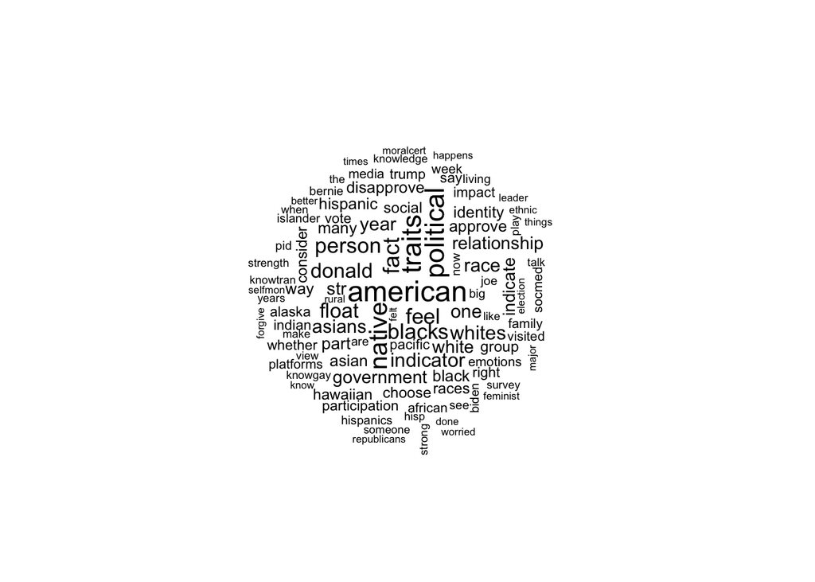

From the wordcloud, the words relate to race (such as blacks,whites,asians,race) appear more time than other words and I am going to process some variables that may relate to this theme from the data of Time Series Cumulative Data from 1952 to 2016

Step2:Process the data

```r
Election_years=as.character(seq(1968, 2016, 4))
anes_dat <-read_sav("~/Desktop/Github/Fall2020-Project1-siranq/data/anes_timeseries_cdf.sav")
anes_use<-anes_dat%>%
mutate(year=as_factor(VCF0004),turnout=as_factor(VCF0703),vote=as_factor(VCF0706),race=as_factor(VCF0105a),age=as_factor(VCF0102),gender=as_factor(VCF0104),education=as_factor(VCF0110))%>%
filter(year %in% Election_years)
anes_dat$VCF0102<-remove_labels(anes_dat$VCF0102)
anes_dat$VCF0102[anes_dat$VCF0102==c("1")]<-c("17-24")
anes_dat$VCF0102[anes_dat$VCF0102==c("2")]<-c("25-34")
anes_dat$VCF0102[anes_dat$VCF0102==c("3")]<-c("35-44")
anes_dat$VCF0102[anes_dat$VCF0102==c("4")]<-c("45-54")
anes_dat$VCF0102[anes_dat$VCF0102==c("5")]<-c("55-64")
anes_dat$VCF0102[anes_dat$VCF0102==c("6")]<-c("65-74")
anes_dat$VCF0102[anes_dat$VCF0102==c("7")]<-c("75-99 and over")
data.table(anes_use%>%
select(year, turnout, vote, race,age, gender,education)%>%
filter(!is.na(turnout))%>% sample_n(10))
```

```
##     year                             turnout
##  1: 2012     2. Registered, but did not vote
##  2: 1968               3. Voted (registered)
##  3: 1988               3. Voted (registered)
##  4: 2012               3. Voted (registered)
##  5: 1980               3. Voted (registered)
##  6: 1984               3. Voted (registered)
##  7: 1972 1. Not registered, and did not vote
##  8: 2016               3. Voted (registered)
##  9: 2012     2. Registered, but did not vote
## 10: 1992     2. Registered, but did not vote
##                                                          vote
##  1:                                                      <NA>
##  2:                                               1. Democrat
##  3:                                             2. Republican
```

[output cut: 29 more lines]

```r
save(anes_use, file="~/Desktop/Github/Fall2020-Project1-siranq/output/data_use.RData")
```

Step3:Simple analysis

3.1 Education level

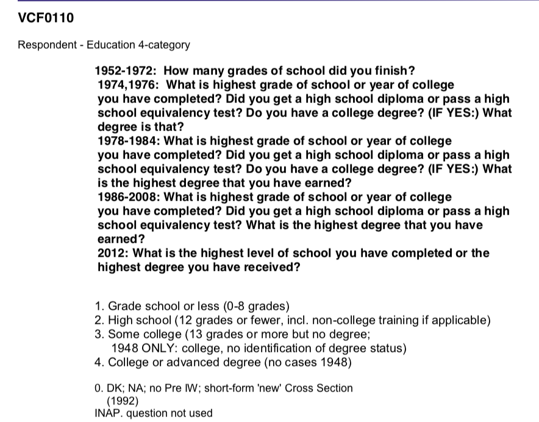

How did the proportions of each racial group in education level change?

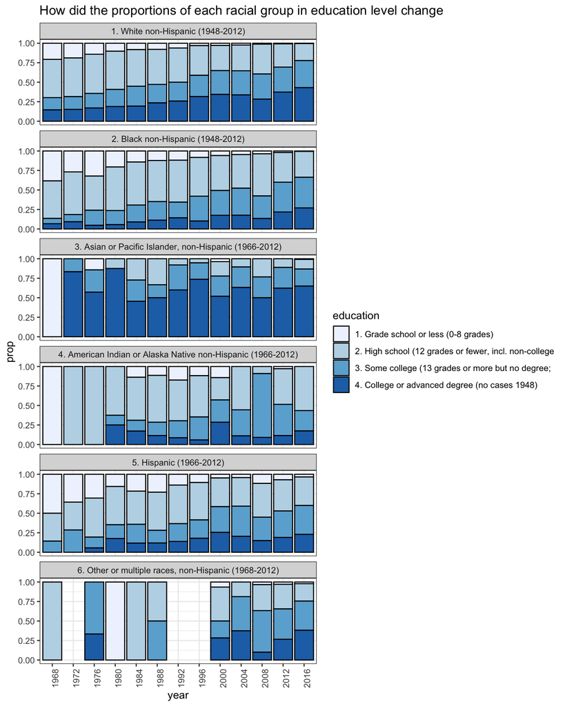

```r
load(file="~/Desktop/Github/Fall2020-Project1-siranq/output/data_use.RData")
anes_to_race_edu = anes_use %>%
filter(!is.na(race) & !is.na(education) &!is.na(turnout))%>%
group_by(year,education,race)%>%
count(education)%>%
group_by(year,race)%>%
mutate(prop=n/sum(n))

ggplot(anes_to_race_edu,aes(x=year,y=prop,fill=education),rep="best")+
geom_bar(stat="identity", colour="black")+
facet_wrap(~race, ncol=1)+
theme_bw()+
theme(axis.text.x=element_text(angle=90))+
scale_fill_brewer(palette="Blues")+
labs(title="How did the proportions of each racial group in education level change")
```

Story 1: From the graph above, I discover that both the proportions of high education level of White non-Hispanic and Black non-Hispanic respondent grew from 1968 to 2016 but the interesting thing is that the proportion of high education level of Asians or Pacific Islander non-Hispanic varies from 1968 to 2016. It absolutely makes sense that in 1968 all the Asian respondent is grade school or less because at that time most of them were immigrants. My guess of reason of this variation is that the number of Asian respondent is not as much as White and Blacks.

Wait!Let’s see an old news!

[figure not shown]

[figure not shown]

3.2 Who voted?

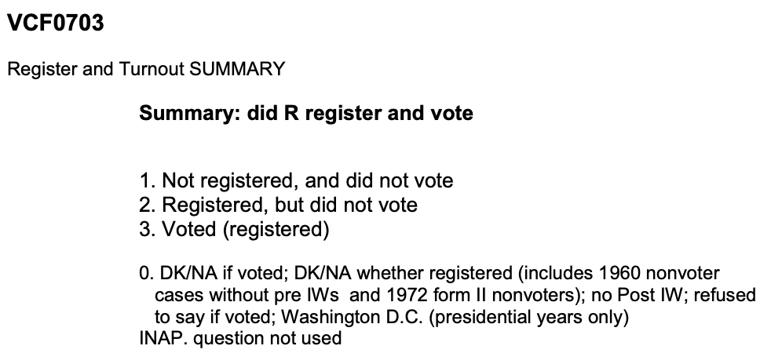

How did the proportions of each racial group who voted change?

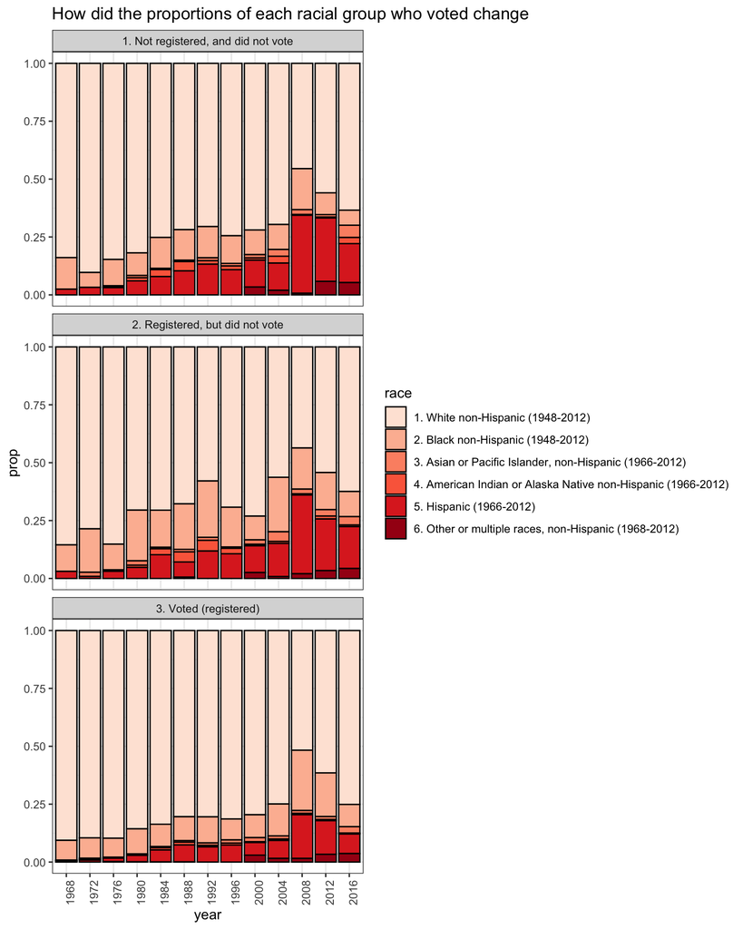

```r
anes_to_race_year = anes_use %>%
  filter(!is.na(race) & !is.na(turnout))%>%
  group_by(year, turnout,race)%>%
  count(race)%>%
  group_by(year,turnout)%>%
  mutate(
    prop=n/sum(n)
  )

ggplot(anes_to_race_year,
       aes(x=year, y=prop, fill=race)) +
  geom_bar(stat="identity", colour="black") + facet_wrap(~turnout, ncol=1) + theme_bw()+
  theme(axis.text.x = element_text(angle = 90))+
  scale_fill_brewer(palette="Reds")+
  labs(title="How did the proportions of each racial group who voted change")
```

Story 2: From the graph above, we can see that although from past to present the respondents were mainly White non-Hispanic, the races of respondents has had more diversity from 1968 to 2016. Especially, during 2008, the proportions of all the racial groups other than Whites enlarged. Guess why? Yes,it is because of him.

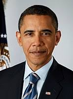

The first Black President in U.S.A. Hence, people may pay more attention to vote.

3.3 Age

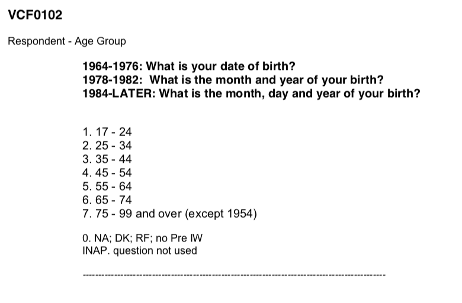

How did the proportions of each racial group in different age groups change?

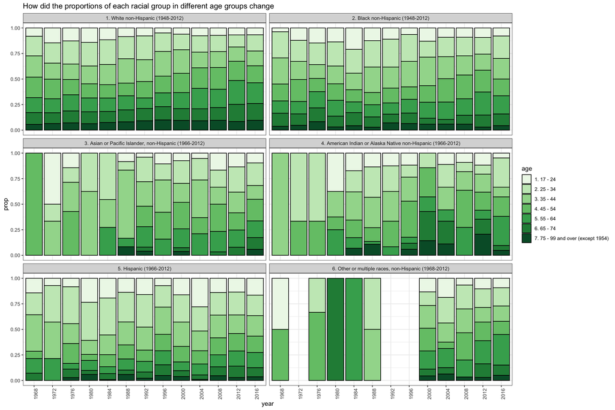

```r
anes_to_race_edu = anes_use %>%
filter(!is.na(race) & !is.na(age) &!is.na(turnout))%>%
group_by(year,age,race)%>%
count(age)%>%
group_by(year,race)%>%
mutate(prop=n/sum(n))

ggplot(anes_to_race_edu,aes(x=year,y=prop,fill=age))+
geom_bar(stat="identity", colour="black")+
facet_wrap(~race, ncol=2)+
theme_bw()+
theme(axis.text.x=element_text(angle=90))+
scale_fill_brewer(palette="Greens")+
labs(title="How did the proportions of each racial group in different age groups change")
```